# Lung timecourse interpretability

Joel Eliason

6/18/2021

This notebook contains my work on interpretable ML for gene expression analysis. In particular, I use a publicly available longitudinal single-cell RNA seq dataset of lung cancer cells and train a boosted trees model to predict timepoint at which a cell was sampled, based on its gene expression values. I then examine the SHAP values (an interpretability framework for feature importance) from this model using TreeSHAP and attempt to discern whether or not SHAP values give us additional insight beyond what a typical differential expression analysis might give.

```r
# path = '/media/joeleliason/Data/lung_timecourse/SCP971/other/ltraw.mat'
#
# r = readMat(path)
#
# counts = r$rawCount
#
# colnames(counts) = unlist(r$sampleID, recursive = FALSE)
# rownames(counts) = unlist(r$geneSymbol, recursive = FALSE)
#
# # counts = counts[,-grep('_4w_',colnames(counts))]
# sce = SingleCellExperiment(assays = list(counts = counts))
#
# sce$typeID = do.call(c, unlist(r$typeID, recursive=FALSE))
#
# spl = strsplit(sce$typeID,'_')
# weeks = sapply(spl, function(x) x[3])
# sce$weeks = weeks
#
# # sce$geneID = do.call(c, unlist(r$geneID, recursive=FALSE))
#
# rm(r,counts,spl)
#
# sce = devianceFeatureSelection(sce, assay="counts", sorted = TRUE, batch = as.factor(sce$typeID))
# saveRDS(sce, "lung_timecourse/SCP971_sce.rds")

sce = readRDS("lung_timecourse/SCP971_sce.rds")
```

We will need to perform some feature selection here - we currently have 52638 features (genes) in the sce, so we will need to take it to somewhere closer to 1000-2000. After this, we can perform cross-validated training using XGBoost, after which we can briefly evaluate performance and then get on to the interpretation (including using SHAP values and looking at interesting interactions).

We’ll be using the binomial deviance as our feature selection method, which has some better qualities to it than using (for example) the variance of that gene (after correcting for heteroscedasticity).

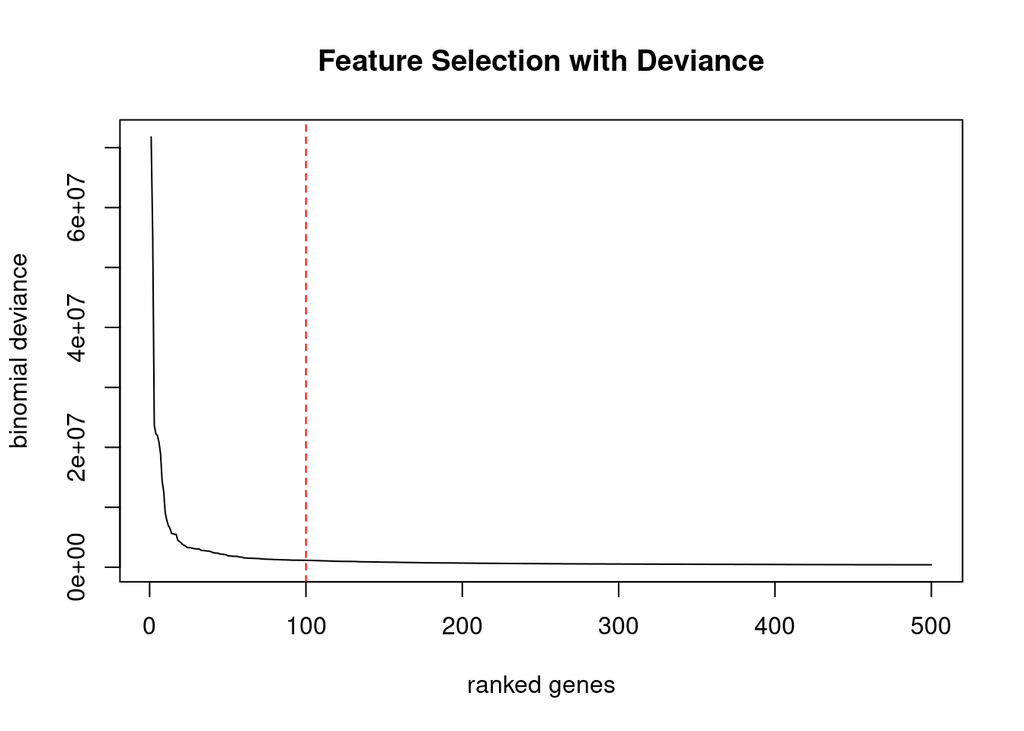

```r
sce = sce[1:500,]

plot(rowData(sce)$binomial_deviance, type="l", xlab="ranked genes",
     ylab="binomial deviance", main="Feature Selection with Deviance")
abline(v=100, lty=2, col="red")
```

Now let’s actually train an xgboost model on this data set.

```r
# X = t(assay(sce, "counts"))
#
# y = factor(sce$weeks, levels = c("early","2w","12w","18w","20w","30w"))
#
# levels(y)
# y = as.numeric(y) - 1
#
#
#
# params = list(max_depth=6, eta=0.05, objective = "multi:softmax", num_class = 6)
# cv.m = xgb.cv(params = params, data = X, label = y, nrounds = 10, nfold = 5, verbose = 1)
```

```r
# ## 75% of the sample size
# smp_size <- floor(0.8 * nrow(X))
#
# ## set the seed to make your partition reproducible
# set.seed(123)
# train_ind <- sample(seq_len(nrow(X)), size = smp_size)
#
# trainX <- X[train_ind, ]
# valX <- X[-train_ind, ]
#
# trainY = y[train_ind]
# valY = y[-train_ind]
#
# train = xgb.DMatrix(trainX, label=trainY)
# val = xgb.DMatrix(valX, label=valY)
#
# watchlist = list(train=train,eval=val)
#
# m = xgb.train(params, train, nrounds = 500, early_stopping_rounds = 5, watchlist=watchlist)
#
# xgb.save(m, "lt_model.model")
#
# write.csv(as.data.frame(as.matrix(X)), "lt_X_500.csv")
#
# write.csv(y, "lt_y.csv")
```

### Interpretable ML using SHAP values with XGBoost model

```r
use_condaenv("bioinfo")

source_python("read_npy_file.py")
shap_values <- read_npy_file("shap_values_500.npy")

base_values <- read_npy_file("base_values_500.npy")

X_500 = read.csv("lt_X_500.csv")

feature_names = colnames(X_500)[-1]

rm(X_500)

y = read.csv("lt_y.csv")$x
```

```r
ngenes = 300
N = dim(shap_values)[1]
nclass = dim(shap_values)[3]

# top n genes per sample in each cluster
# top_ngenes = apply(shap_values, 1, function(sample) {
#   apply(sample, 2, function(class) {
#     list(feature_names[order(abs(class), decreasing = TRUE)[1:N]])
#   })
# })
#
# rm(top_ngenes)

# top n genes per sample in their actual cluster
top_ngenes_1Class = sapply(1:N, function(samp_ix) {
    list(feature_names[order(abs(shap_values[samp_ix,,(y[samp_ix]+1)]), decreasing = TRUE)[1:ngenes]])
})

mean_shaps_PerClass = sapply(1:nclass, function(class_ix) {
  mean_shaps = colMeans(shap_values[,,class_ix])
})

# top n genes per class
top_ngenes_PerClass = sapply(1:nclass, function(class_ix) {
  mean_shaps = mean_shaps_PerClass[,class_ix]
  genes = feature_names[order(abs(mean_shaps), decreasing = TRUE)[1:ngenes]]
  shaps = mean_shaps[order(abs(mean_shaps), decreasing = TRUE)[1:ngenes]]
  df = list(as.data.frame(cbind(genes,shaps)))
})
```

```r
# Dimensionality reduction.
# set.seed(1234)
# sce <- runPCA(sce, ncomponents=40, subset_row=hvg)
# # sce = runNMF(sce, ncomponents = 25, subset_row=hvg)
# sce <- runUMAP(sce, dimred = 'PCA', external_neighbors=TRUE)

sce <- logNormCounts(sce)

# markers = findMarkers(sce, groups = y, direction = "up", lfc = 1.5, test="wilcox", pval.type = "some")

# de = sapply(markers, function(marker) {
#   marker[marker$FDR<0.01 & marker$summary.AUC > 0.6,]
# })

markers = findMarkers(sce, groups = y, lfc = 1)

# Intersection per cluster between SHAP set and marker set
sapply(1:nclass, function(cluster) {
  cur.markers = markers[[cluster]]
  length(intersect(rownames(cur.markers), top_ngenes_PerClass[[cluster]]$genes))
})
```

```
## [1] 284 287 284 286 286 283
```

```r
# Intersection per cluster between SHAP set and DE set (can define DE in different ways, but with similar results)
sapply(1:nclass, function(cluster) {
  cur.markers = markers[[cluster]]
  best.set = cur.markers[cur.markers$Top <= 7,]
  length(intersect(rownames(best.set), top_ngenes_PerClass[[cluster]]$genes))
})
```

```
## [1] 25 21 19 16 17 17
```

So the genes are very likely to be included in the markers set, but quite unlikely to be in a ‘differentially expressed’ set, however defined (whether from Top or from AUC and FDR).

Should also check for concordance or ranking differences between the two:

```r
# Difference in rankings per cluster between marker set and SHAP set
diff_rank = sapply(1:nclass, function(cluster) {
  genes = top_ngenes_PerClass[[cluster]]$genes
  cur.markers = markers[[cluster]]
  filt.markers = cur.markers[rownames(cur.markers) %in% genes,]
  sapply(1:ngenes, function(x) {
    idx = which(genes[x] == rownames(filt.markers))[1]
    diff = x - idx
})
})

head(diff_rank)
```

```
##      [,1] [,2] [,3] [,4] [,5] [,6]
## [1,]    0  -17   -6   -1   -3  -12
## [2,]   -3   -2  -39   -1   -7   -1
## [3,]   NA -235    1   -1   -7   NA
## [4,]   -2  -21  -24   -4 -275  -81
## [5,]  -31  -30   NA   -4   -3   NA
## [6,]  -10  -30  -93   -1  -55    4
```

```r
# Per cluster gene list including SHAP value and marker data
top_ngenes_PerClass = sapply(1:nclass, function(cluster) {
  cur.markers = markers[[cluster]]
  cur.markers = cur.markers[,1:3]
  cur.markers$genes = rownames(cur.markers)
  joined = dplyr::right_join(tibble::as_tibble(cur.markers), tibble::as_tibble(top_ngenes_PerClass[[cluster]]), by = "genes")
  joined$shaps = as.numeric(joined$shaps)
  list(joined[order(abs(joined$shaps), decreasing = TRUE),])
})

top_ngenes_PerClass[[3]]
```

```
## # A tibble: 300 x 5
##      Top    p.value        FDR genes        shaps
##    <int>      <dbl>      <dbl> <chr>        <dbl>
##  1     2  3.08e- 65  1.10e- 63 Gm26825    -0.225
##  2    19  7.95e- 21  4.91e- 20 Rpl32      -0.195
##  3     1  7.53e-139  1.25e-136 Gm15459    -0.109
##  4    12  4.91e- 28  4.31e- 27 Rps7       -0.0900
##  5    NA NA         NA         mt.Atp6    -0.0608
##  6    52  2.39e-  8  7.25e-  8 Rpl21      -0.0572
##  7    65  1.82e-  5  4.27e-  5 Rps3a3     -0.0515
##  8    10  2.14e- 26  1.70e- 25 Ppp1r14c   -0.0504
##  9   380  1   e+  0  1   e+  0 CT010467.1 -0.0382
## 10    17  6.18e- 26  4.83e- 25 Lgi3       -0.0358
## # … with 290 more rows
```

```r
# Recall that now, genes are NOT in the same order as in feature_names!
```

It seems like they are agreeing that the top 5 or so genes are similarly important, but after that it is harder to tell. Could just be noise in the training as well.

How do these differences in top genes (ranked by SHAP) and top DE genes change the gene ontology? What overlap is there in these two lists, beyond genes, but in actual ontology?